# Test 1 Review Questions

## Problem 1

### Question

The below plot shows the distribution of ages from passengers aboard the Titanic. Use it to answer the following parts.

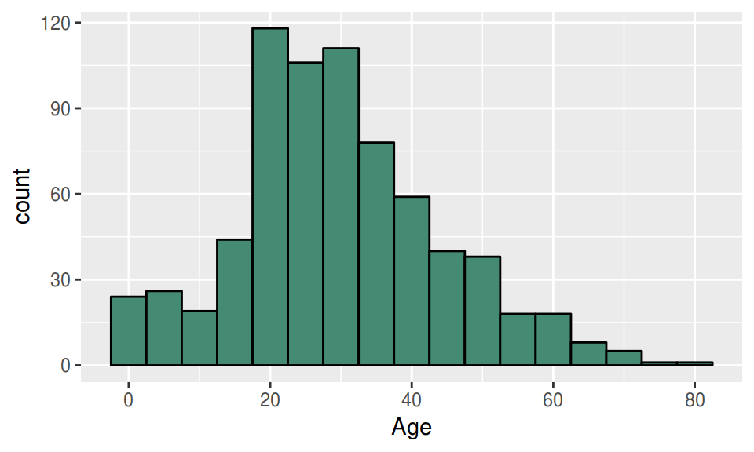

1. Would you describe this data as coming from an observational study or experiment?
2. Approximately where does the center of the distribution lie?
3. Describe the shape of the distribution.
4. Would describing the center of the distribution by the mean or median be more robust against possible outliers?

### Solutions

1. Given that this is data gleaned from looking at passenger records, this is surely an observational study. It would be rather unethical to sentence people to death by drowning…
2. The center of the distribution looks to lie around 25 or so years of age, as evidenced by where the peak of the distribution lies.
3. The distribution is unimodal with a peak around 25 years and slightly skewed right. Which makes sense since many more people can be older than 25 than can be younger than 25.
4. Because this data is skewed, the median should be more robust against outliers. The mean and standard deviation are best for more symmetric distributions.

## Problem 2

### Question

Suppose you want to investigate to see whether or not the age of passengers is associated to whether or not they survived.

1. Determine what the explanatory and response variables are in this case, and identify what type of variable each is.
2. The plot below shows a comparison of the two variables. Do they seem to be independent or dependant? How can you tell?
3. Given the type of study this is, what could you conclude concerning correlations or causations between the two variables?

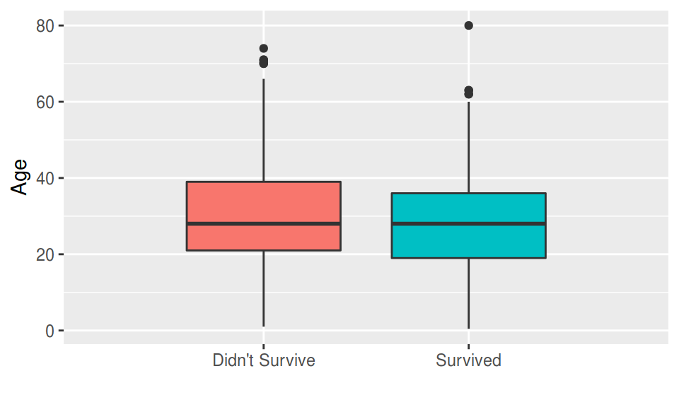

### Solutions

1. The explanatory variable here would be age and the response variable whether they survived or not. Age is a numeric variable, probably discrete since one one lists their age with a decimal. Survived or not is a categorical variable, one which I’d call regular as I don’t think there is a natural ordering to surviving or not.
2. Based on that plot, they seem pretty independent to me. Both median ages are nearly identical, and the spread of each is very similar. Survivors have a slightly younger age on the high end, but that is the only real difference. So just off the plot, I’d say they look the same and thus are independent.
3. This was an observational study, so at best we could make conclusions about correlation. Only experiments can make claims about causation. And in this particular case, the two variables don’t even seem to be highly correlated.

## Problem 3

### Question

Suppose instead you were interested in a possible relationship between the class of ticket a passenger recieved (1st class being the best) and the amount that they paid for said ticket. The plot and summary below show the results of a least-squares linear fit to the data. Use them to answer these questions.

1. Write out the equation describing the shown linear fit.
2. What percentage of the variance in `Fare` is explained by this model?
3. Miss Elizabeth Bonnell received a 1st class ticket for $26.55. What is her corresponding residual with the model?
4. How much more on average would a 1st class ticket cost than a 3rd class ticket?
5. What (if any) meaning does the intercept have in this case?
6. Are there any outliers? How would you classify them?

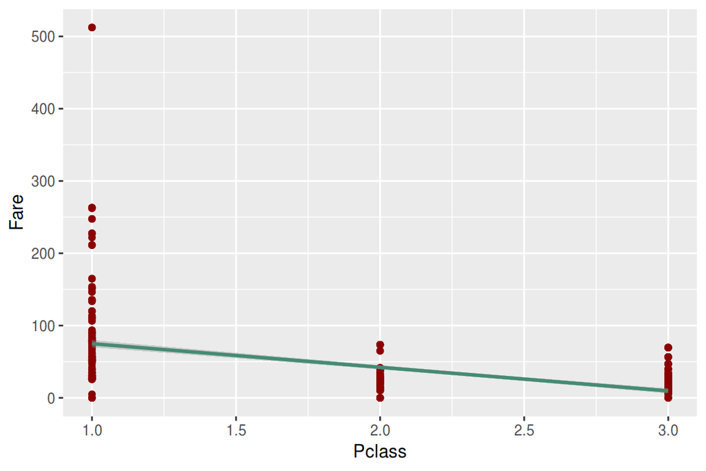

```
##
## Call:
## lm(formula = data$Fare ~ data$Pclass)
##
## Residuals:
##    Min     1Q Median     3Q    Max
## -74.95 -16.63  -1.79   4.83 437.38
##
## Coefficients:
##             Estimate Std. Error t value Pr(>|t|)
## (Intercept)  107.606      4.089   26.32   <2e-16 ***
## data$Pclass  -32.661      1.666  -19.61   <2e-16 ***
## ---
## Signif. codes:  0 '***' 0.001 '**' 0.01 '*' 0.05 '.' 0.1 ' ' 1
##
## Residual standard error: 41.54 on 889 degrees of freedom
## Multiple R-squared:  0.3019, Adjusted R-squared:  0.3012
## F-statistic: 384.5 on 1 and 889 DF,  p-value: < 2.2e-16
```

### Solutions

1. The equation would look like:
   $$\widehat{Fare} = 107.606 - 32.661 \times (Passenger~class)$$
2. As evidenced by the multiple $R^2$ value, about 30% of the variance in the Fare seems to be explained by this model.
3. Our equation would predict a first class ticket to cost:
   $$107.606 - 32.661 \times (1) = 74.945$$
   Since the residual is given by $y - \hat y$, then we have a residual of $26.55-74.945 = -48.395$. As such we see that our model grossly over-estimates the fare for Miss Elizabeth.
4. The slope indicates that for each point increase in the fare, our fare drops by 32.661. As such, moving from a 1st class ticket to a third class moves us 2 points, and thus 3rd class tickets should on average by 65.32 dollars (or pounds, or whatever this unit of money is) cheaper.
5. The intercept in this case would correspond to a `pclass` of 0, which doesn’t really make any sense or exist. As such, the intercept has no real meaning here and just serves to shift the least-squares line up or down.
6. The biggest outlier I see in the 1st class ticket which sold for over 500. While not super far from the bulk of the data, it is at the edge and far above the average. As such I’d probably call it influential here. I could easily see the slope shifting down a little were that point not present.

## Problem 4

### Question

Of more interest perhaps would be the ability to predict who survived and did not based off the available variables. Here you take gender (`Sex`) and passenger class (`Pclass`) to be your explanatory variables, and surviving will equate to a 1 and dying a 0. In a bit of a naive approach you try simple multiple regression, and the results are shown below.

```
##
## Call:
## lm(formula = data$Survived ~ data$Sex + data$Pclass)
##
## Residuals:
##     Min      1Q  Median      3Q     Max
## -0.9252 -0.2505 -0.0925  0.2328  0.9075
##
## Coefficients:
##              Estimate Std. Error t value Pr(>|t|)
## (Intercept)   1.08327    0.04028   26.89   <2e-16 ***
## data$Sexmale -0.51667    0.02740  -18.85   <2e-16 ***
## data$Pclass  -0.15803    0.01567  -10.09   <2e-16 ***
## ---
## Signif. codes:  0 '***' 0.001 '**' 0.01 '*' 0.05 '.' 0.1 ' ' 1
##
## Residual standard error: 0.3874 on 888 degrees of freedom
## Multiple R-squared:  0.3677, Adjusted R-squared:  0.3663
## F-statistic: 258.2 on 2 and 888 DF,  p-value: < 2.2e-16
```

1. Explain what the slope corresponding to `data$Sexmale` means.
2. Who would your model predict is more likely to survive: a 1st class male or a 3rd class female?
3. Suppose you added `Age` as another explanatory variable. The results of that model are shown below. Is this new model better or worse than the old model? Why?

```
##
## Call:
## lm(formula = data$Survived ~ data$Sex + data$Pclass + data$Age)
##
## Residuals:
##      Min       1Q   Median       3Q      Max
## -1.11224 -0.25417 -0.06352  0.22700  1.00737
##
## Coefficients:
##               Estimate Std. Error t value Pr(>|t|)
## (Intercept)   1.326066   0.062606  21.181  < 2e-16 ***
## data$Sexmale -0.479293   0.030671 -15.627  < 2e-16 ***
## data$Pclass  -0.202916   0.018891 -10.741  < 2e-16 ***
## data$Age     -0.005453   0.001082  -5.042 5.86e-07 ***
## ---
## Signif. codes:  0 '***' 0.001 '**' 0.01 '*' 0.05 '.' 0.1 ' ' 1
##
## Residual standard error: 0.3846 on 710 degrees of freedom
##   (177 observations deleted due to missingness)
## Multiple R-squared:  0.3902, Adjusted R-squared:  0.3876
## F-statistic: 151.4 on 3 and 710 DF,  p-value: < 2.2e-16
```

### Solutions

1. The slope value for the `Sexmale` value shows the drop in survival rate if a passenger is male. So here we see that males are about 1/2 as likely to live.
2. Plugging in the values, we have that:
   $$1.0837 - 0.51667 \times (1) - 0.15803 \times (1) = 0.409$$
   $$1.0837 - 0.51667 \times (0) - 0.15803 \times (3) = 0.609$$
   And thus we see that the 1st class male still has a lower chance of surviving than the 3rd class female.
3. The second model seems to have a slightly higher adjusted $R^2$ value, which means it is capturing more of the variability in the survival rate than the original. So I’d probably conclude that it is a slightly better model.

## Problem 5

### Question

We saw `Age` was mostly independent of survival, here we will assume that it is entirely independent. Of the whole passenger list, only 38.4% of the passengers survived. 18.4% of the passengers were under the age of 20. What are the odds that a randomly chosen passenger off the list would be over the age of 20 and survive?

### Solutions

Since we showed earlier that survival and age are independent, here we are adding the effects of independent outcomes, and as such will use the multiplication rule. We know the probability of surviving, so we just need to find the probability of a passenger being over the age of 20. Or actually 20 or above, I probably should have made that more clear. The probability of being under 20 is 18.4%, so the probability of being 20 or above is 81.6%. The probability of being both 20 or older and surviving then is just:
$$0.384 \times 0.816 = 0.313$$
Or about 31%.

## Problem 6

### Question

Is the below plot a valid probability distribution of the passenger class? Explain why or why not. No passenger is in two classes, and all passengers are in some class.

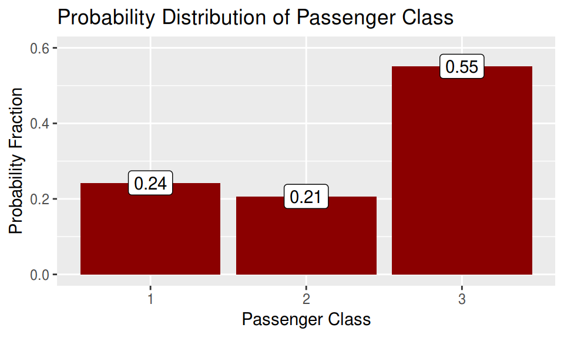

### Solutions

We require 3 things to be a probability distribution:

- All events must be disjoint: Here, you can only be in a single passenger class, never 2. As such, each passenger class is disjoint, so this is satisfied.
- The probabilities must all be between 0 and 1: Yup, this looks to be the case
- Adding all the probabilities must total to 1: Adding up $0.24 + 0.21 + 0.55 = 1$, so this looks good as well!

Since all three conditions are met, this would be a valid probability distribution describing the odds of a passenger being in any particular class.